# Runoff Peaks Plots

Daniel Klotz, Johannes Wesemann

22 September 2016

# 1 Introduction

The function `plotlist_runoffpeaks` lets users explore the highest events in among the available basins. It provides a list of [ggplot2](http://ggplot2.org/) plots, containing an overview plot (`overview`), a scatter plot (`scatter`) and detail plots of the individual events (`event_plot`). Instead of explaining the properties of each plot in detail it is best to get an intuition of the function by looking at some examples.

The function takes tree arguments:

| argument | explenation |
| --- | --- |
| runoff_data | `data.frame` as used within visCOS |
| n_events | number of events to be searched |
| window_size | Extension of individual events |

## 1.1 Examples:

For the examples 10 events are extracted from a runoff example

```r
  require(visCOS)
  runoff_data <- get_runoff_example()
  peakplots <- plotlist_runoffpeaks(runoff_data, n_events = 10L)
```

The `peakplots` list does now contain plots for each basin within the `runoff_data` data.frame:

```r
  names(peakplots)
```

```
## [1] "basin0001" "basin0002"
```

For each basin the a set of plots (`overview`,`scatter`,`event_plot`) are saved within a list for each basin. In the following the plots for basin 1 are shown:

```r
  names(peakplots$basin0001)
```

```
##  [1] "overview"     "scatter"      "event_plot1"  "event_plot2"
##  [5] "event_plot3"  "event_plot4"  "event_plot5"  "event_plot6"
##  [9] "event_plot7"  "event_plot8"  "event_plot9"  "event_plot10"
```

The `overview` plot shows the entire time series of `data1` and `data2` of the basin. The found events are marked with black dots. The `overview` plot for basin 1 is:

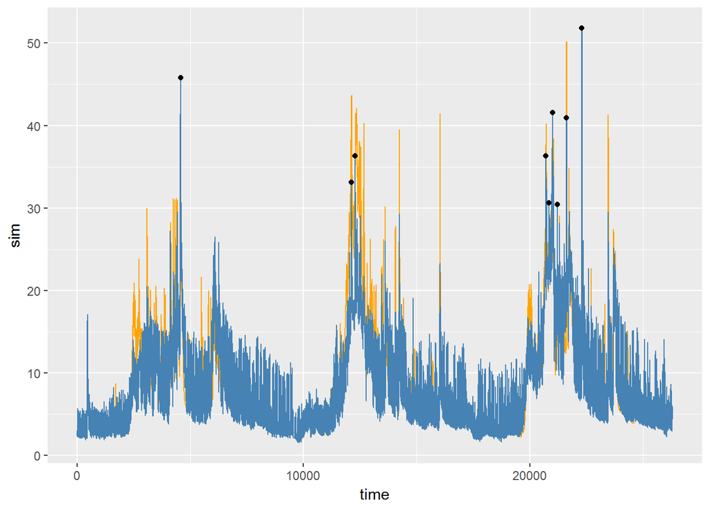

```r
  peakplots$basin0001$overview
```

The `scatter` plot shows the found events within a scatter plot, where `data1` is the x-axis and `data2` on the y-axis. In the followin an example for basin 1 is given.

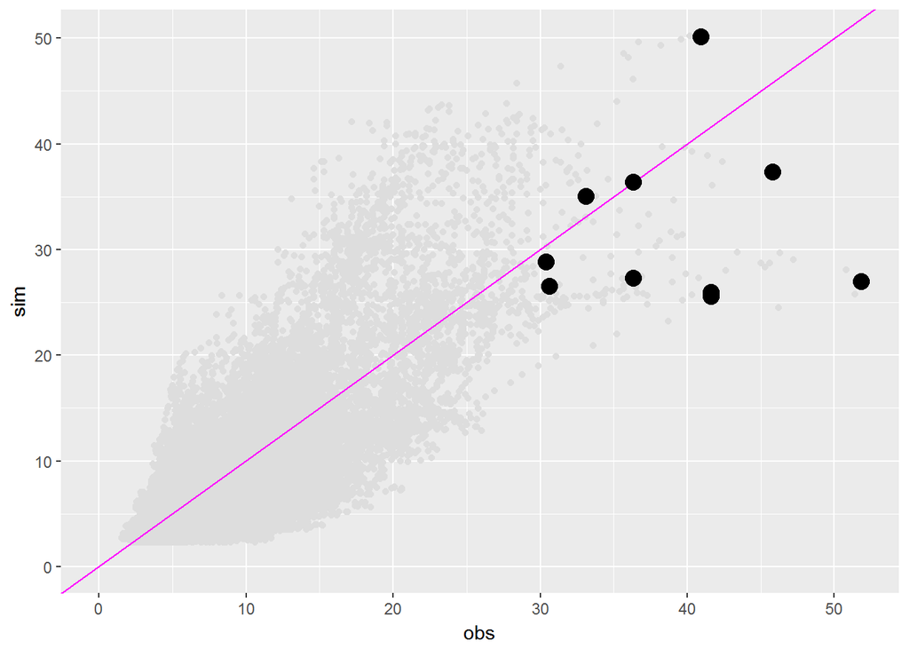

```r
  peakplots$basin0001$scatter
```

Detail plots for each of the found events are given in form of the `event_plot` objects. Here an example:

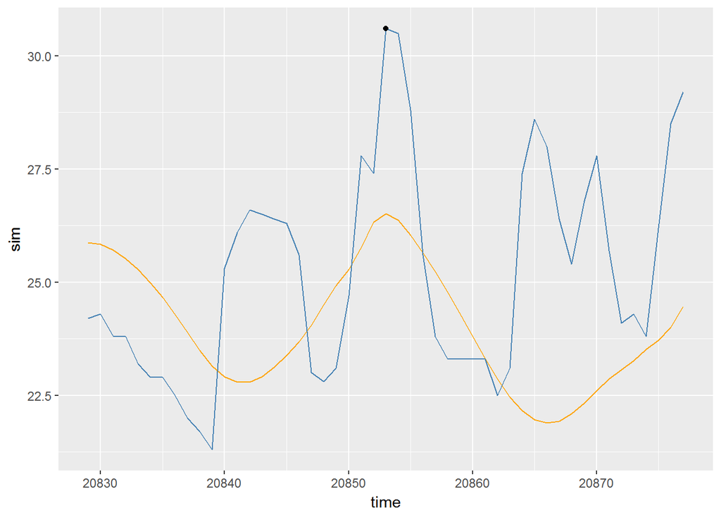

```r
  peakplots$basin0001$event_plot5
```

# 2 Code

This part of the document defines the code of `plotlist_runoffpeaks`

```r
#' Plot List for Runoff Peaks
#' @export
#'
#' @import ggplot2
#' @import dplyr
#' @import magrittr
#' @importFrom tibble tibble
plotlist_runoffpeaks <- function(runoff_data,
                                 n_events= 10L,
                                 window_size = 24L) {
  # pre:
  assert_dataframe(runoff_data)
  n_events_int <- as.integer(n_events)
  window_size_int <- as.integer(window_size)
  if( is.na(n_events_int)  |
      is.nan(n_events_int) |
      is.infinite(n_events_int) |
      !is.integer(n_events_int) ) {
    stop("n_events is ill defined")
  }
  if( is.na(window_size)  |
      is.nan(window_size) |
      is.infinite(window_size) |
      !is.integer(window_size) ) {
    stop("window_size is ill defined")
  }
  data1 <- runoff_data %>%
     select( starts_with(viscos_options("name_o")) )
  data2 <- runoff_data %>%
     select( starts_with(viscos_options("name_s")) )
  data_numbers <- names(data1) %>%
    gsub(viscos_options("name_o"),"",.,ignore.case = TRUE) %>%
    gsub("\\D","",.,ignore.case = TRUE)
  # make plotlist:
  plotlist <- lapply(1:ncol(data1), function(x) plotlist_one_basin(data1[,x],
                                                                   data2[,x],
                                                                   n_events_int,
                                                                   window_size_int)) %>%
    set_names(.,paste("basin", data_numbers, sep =""))
  return(plotlist)
}
```

## 2.1 Generating the Plots for one basin.

This is the function for generating the different plots for one basin. At first the provided time series are groupded into a tibble, then the peaks of the observations are obtained via the peak_finder function and organised.Then `ggplot2` is used for plotting.

```r
plotlist_one_basin <- function(qobs,qsim,n_events_int,window_size_int) {
  single_data <- tibble::tibble(time = as.integer(1:length(qobs)),
                                obs = as.double(qobs),
                                sim = as.double(qsim))
  #
  peak_idx <- find_peaks(single_data$obs,m = window_size_int)
  peak_organised <- tibble::tibble(idx = as.integer(peak_idx),
                           peak_obs = single_data$obs[peak_idx],
                           peak_sim = single_data$sim[peak_idx])
  highest_peaks_organised <- peak_organised$peak_obs %>%
    sort(decreasing = TRUE) %>%
    .[1:n_events_int] %>%
    '%in%'(peak_organised$peak_obs,.) %>%
    which( . ) %>%
    peak_organised[., ]
  #
  overview_plot <- ggplot() +
    geom_line(data = single_data,aes(x = time, y = sim), col = viscos_options("color_data2")) +
    geom_line(data = single_data,aes(x = time, y = obs), col = viscos_options("color_data1")) +
    geom_point(data = highest_peaks_organised, aes(idx, peak_obs))
  overview_scatter <- ggplot() +
    geom_point(data = single_data, aes(obs,sim), color = "#DDDDDD") +
    geom_abline(color = viscos_options("color_of_mid")) +
    geom_point(data = highest_peaks_organised, aes(peak_obs,peak_sim), size = 4) +
    expand_limits(x = 0, y = 0)
  sub_plots <- lapply(1:nrow(highest_peaks_organised),
                      function(x) sub_peakplot_fun(x,window_size_int,highest_peaks_organised,single_data) ) %>%
    set_names(.,paste("event_plot",1:length(.),sep=""))
  return(overview = append(list(overview = overview_plot,scatter = overview_scatter), sub_plots))
}
```

## 2.2 Function to find peaks

The function for finding the peaks was proposed and developed by Propsoed by the cross validated user “stas g” in [this](http://stats.stackexchange.com/questions/22974/how-to-find-local-peaks-valleys-in-a-series-of-data) thread.  
This is by far not the only option/possibility to appraoch the peak finding task. Other nice ideas for finding peaks can be found in [this](http://stats.stackexchange.com/questions/36309/how-do-i-find-peaks-in-a-dataset) cross validated thread.

```r
  ####
  # peak finder function:
  find_peaks <- function (x, m = 3){
    shape <- diff(sign(diff(x, na.pad = FALSE)))
    pks <- sapply(which(shape < 0), FUN = function(i){
      z <- i - m + 1
      z <- ifelse(z > 0, z, 1)
      w <- i + m + 1
      w <- ifelse(w < length(x), w, length(x))
      if(all(x[c(z : i, (i + 2) : w)] <= x[i + 1])) return(i + 1) else return(numeric(0))
    })
    pks <- unlist(pks)
    pks
  }
```

## 2.3 Subplot Function

This function is a wrapper around ggplot, which is used to generate the individual event plots.

```r
  ####
  # sub plot function:
  sub_peakplot_fun <- function(x,window_size,highest_peaks_organised,peak_data) {
    point <- highest_peaks_organised[x,]
    plot_sub <- ggplot() +
      geom_line(data = peak_data[(point$idx - window_size):(point$idx + window_size),],
                aes(x = time, y = sim),
                col = "orange") +
      geom_line(data = peak_data[(point$idx - window_size):(point$idx + window_size),],
                aes(x = time, y = obs),
                col = "steelblue") +
      geom_point(data = point, aes(idx, peak_obs))
    return(plot_sub)
  }
```